# Midterm Practice

Yufei Liu

2025-10-11

# I. Plot and Inference

• Show a time series plot. # Set up

```r
# File path (Windows: use forward slashes)
csv_path <- "C:/Users/l2007/Desktop/文档/Business Forecasting/Week 3/HW3 data_w SCFM project data/l230_nfc_trade_receivables_2000on.csv"

# "C:/Users/l2007/OneDrive/桌面/文档/Business Forecasting/Week 3/HW3 data_w SCFM project data/l230_nfc_trade_receivables_2000on.csv"

# Read raw
df_raw <- readr::read_csv(csv_path, show_col_types = FALSE)

# Normalize to date/value (auto-detect)
date_candidates  <- grep("date|period|time|quarter|qtr", names(df_raw), ignore.case = TRUE, value = TRUE)
date_col         <- if (length(date_candidates)) date_candidates[1] else names(df_raw)[1]
value_candidates <- setdiff(names(df_raw), date_col)
value_col        <- value_candidates[1]

df <- df_raw |>
  dplyr::select(date = !!rlang::sym(date_col), value_raw = !!rlang::sym(value_col)) |>
  dplyr::mutate(date = as.character(date),
                value = readr::parse_number(as.character(value_raw))) |>
  dplyr::filter(!is.na(value)) |>
  dplyr::arrange(date)

# Build quarterly ts from "YYYY Qn"/"YYYYQn"
parse_yq <- function(x){
  s <- gsub(" ", "", x)         # "YYYYQn"
  y <- as.integer(substr(s, 1, 4))
  q <- as.integer(substr(s, nchar(s), nchar(s)))
  cbind(y, q)
}
yq <- parse_yq(df$date)
start_year    <- yq[1,1]
start_quarter <- yq[1,2]

# Data in BILLIONS
y_ts <- ts(df$value, start = c(start_year, start_quarter), frequency = 4)
```

# Plot Time Series

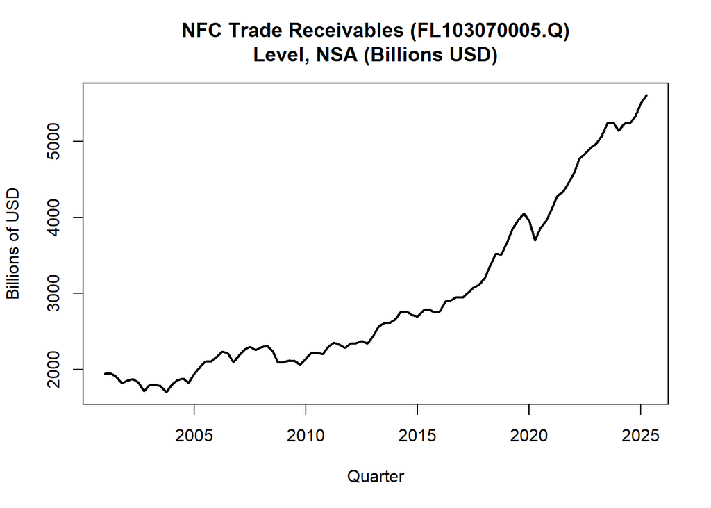

```r
# assumes y_ts is the quarterly series (freq = 4) from HW4
plot(y_ts,main = "NFC Trade Receivables (FL103070005.Q)\nLevel, NSA (Billions USD)",ylab = "Billions of USD", xlab = "Quarter", lwd = 2)
```

• Please summarize your observations of the time series plot The series climbs steadily and has a strong upward trend from 2001 to 2025, with the slope steepening after 2017 and especially post-2020. There is a visible dip around 2020 (COVID pandemic shock) that is followed by a sharp rebound and faster growth to new highs. Fluctuations appear larger in the later years, consistent with the higher level of the series.

• Plot and describe your observations from the Acf

```r
library(forecast)
```

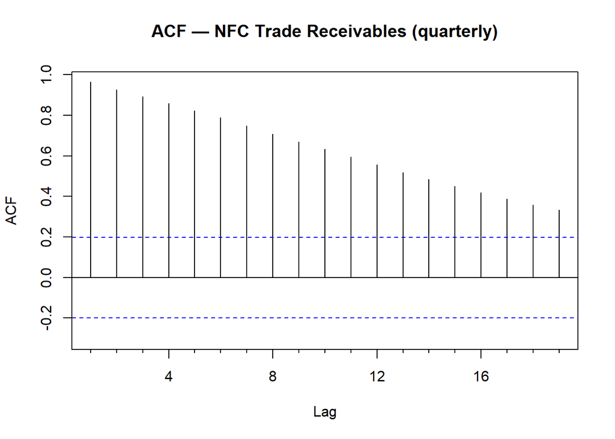

```r
# ACF of the level series (as in Lecture 3)
Acf(y_ts, main = "ACF — NFC Trade Receivables (quarterly)")
```

There’s no obvious repeating pattern every four quarters in the autocorrelation function. The ACF also doesn’t show distinct spikes at lag 4. The ACF tails off slowly rather than cutting off. It decays very slowly from Lag 1 near 1, consistent with a trend that shocks tend to carry forward.

# II. Central Tendency

• What is the min, max, mean, median, 1st, and 3rd Quartile values of the times series?

```r
# Min. 1st Qu. Median Mean 3rd Qu. Max.
summary(as.numeric(y_ts))
```

```
##    Min. 1st Qu.  Median    Mean 3rd Qu.    Max.
##    1702    2117    2503    2953    3692    5606
```

• Show the box plot.

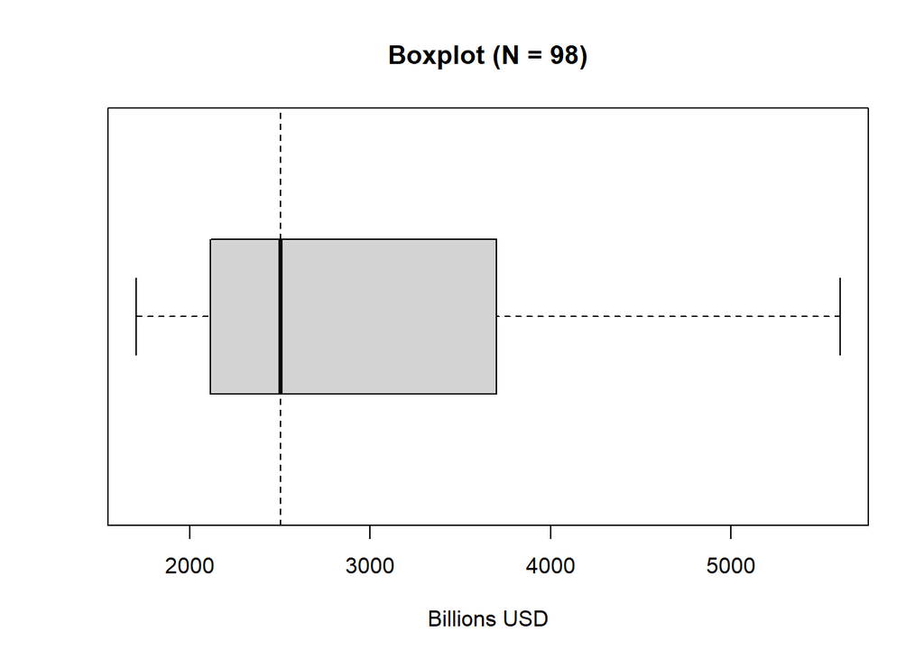

```r
x <- as.numeric(y_ts)
boxplot(x, horizontal = TRUE,
        main = sprintf("Boxplot (N = %d)", length(x)),
        xlab = "Billions USD")
# dashed line at median
abline(v = median(x), lty = 2)
```

# III. Naive Method

• Output

```r
library(forecast)
# 1 year ahead for quarterly data
h <- 4
naive_forecast <- naive(y_ts, h = h)
# prints method, mean forecasts, and prediction intervals
naive_forecast
```

```
##         Point Forecast    Lo 80    Hi 80    Lo 95    Hi 95
## 2025 Q3       5606.114 5492.691 5719.537 5432.649 5779.579
## 2025 Q4       5606.114 5445.710 5766.518 5360.797 5851.431
## 2026 Q1       5606.114 5409.660 5802.568 5305.663 5906.565
## 2026 Q2       5606.114 5379.268 5832.960 5259.183 5953.045
```

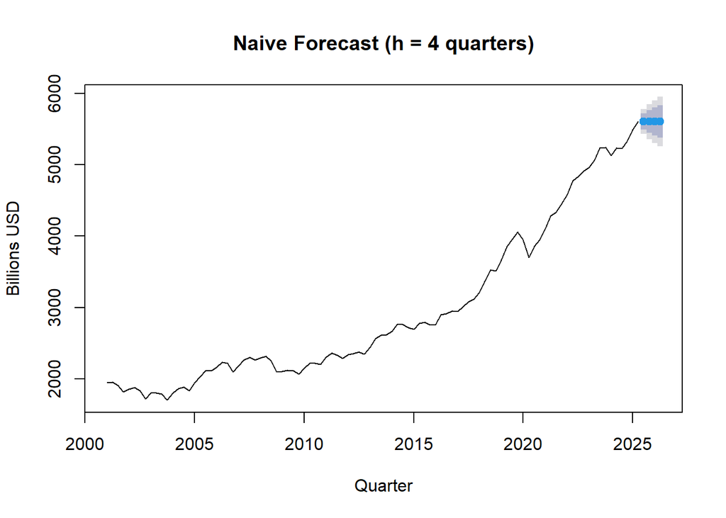

```r
plot(naive_forecast,main = "Naive Forecast (h = 4 quarters)",ylab = "Billions USD", xlab = "Quarter")
```

```r
# Point Forecast, Lo 80/Hi 80, Lo 95/Hi 95
as.data.frame(naive_forecast)
```

```
##         Point Forecast    Lo 80    Hi 80    Lo 95    Hi 95
## 2025 Q3       5606.114 5492.691 5719.537 5432.649 5779.579
## 2025 Q4       5606.114 5445.710 5766.518 5360.797 5851.431
## 2026 Q1       5606.114 5409.660 5802.568 5305.663 5906.565
## 2026 Q2       5606.114 5379.268 5832.960 5259.183 5953.045
```

```r
# last observed value
tail(y_ts, 1)
```

```
##          Qtr2
## 2025 5606.114
```

```r
# the 4 point forecasts
rep(tail(y_ts, 1), h)
```

```
## [1] 5606.114 5606.114 5606.114 5606.114
```

Under the Naive model, each point forecast equals the last observed value (5606.114), while the 80% and 95% prediction intervals provide bands of likely outcomes that widen as the forecast horizon increases due to accumulating uncertainty.

• Perform Residual Analysis for this technique. o Do a plot of residuals. What does the plot indicate?

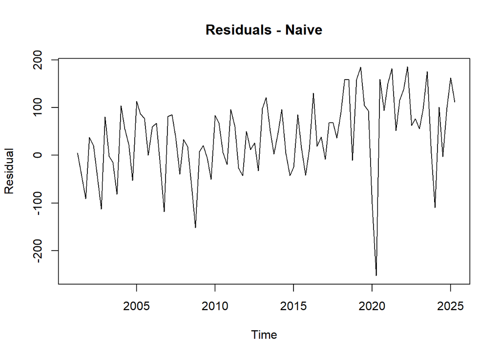

```r
res_n <- residuals(naive_forecast)
plot(res_n, main = "Residuals - Naive", ylab = "Residual")
```

Centered roughly around 0, but variance grows over time (later years swing more). Many positive residuals after 2017 indicate that the naive (last-value) under-forecasts during sustained growth. Large negative spikes (e.g., 2020, 2024) when the series drops suddenly indicate naive over-forecasts after shocks. Not IDD noise. There are signs of heteroskedasticity and regime shifts that naive models can’t capture.

o Do a Histogram plot of residuals. What does the plot indicate?

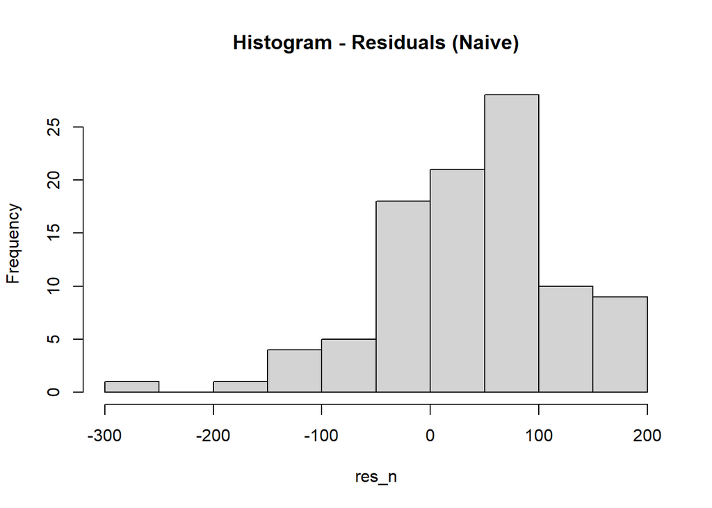

```r
hist(res_n, breaks = "FD", main = "Histogram - Residuals (Naive)")
```

o Do a plot of fitted values vs. residuals. What does the plot indicate?

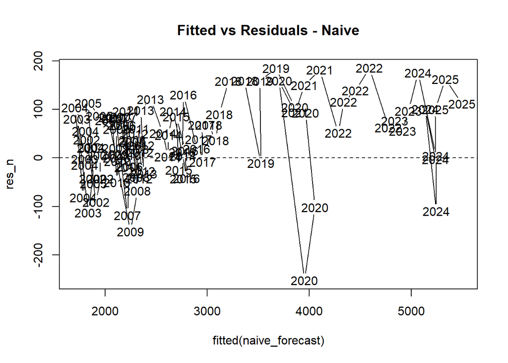

```r
plot(fitted(naive_forecast), res_n, pch = 16,main = "Fitted vs Residuals - Naive");abline(h = 0, lty = 2)
```

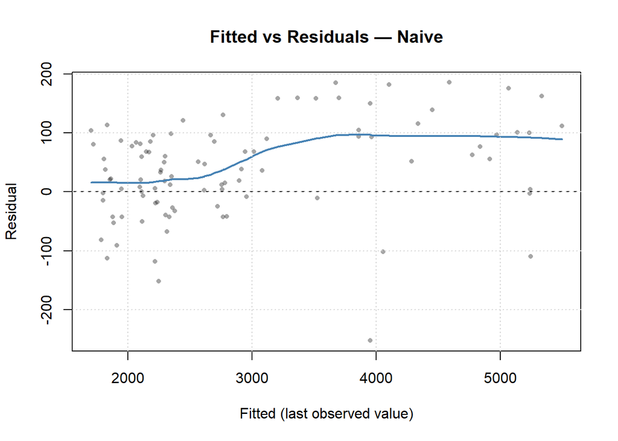

```r
# smaller points + transparency + smooth + grid
f <- as.numeric(fitted(naive_forecast))
r <- as.numeric(res_n)
# drop any NA/Inf
ok <- is.finite(f) & is.finite(r)
f2 <- f[ok]; r2 <- r[ok]
plot(f2, r2,
     pch = 16, cex = 0.7,
     col = rgb(0, 0, 0, 0.35),
     xlab = "Fitted (last observed value)",
     ylab = "Residual",
     main = "Fitted vs Residuals — Naive")
abline(h = 0, lty = 2)
# compute, then draw the smooth explicitly
# robust smoother
lw <- lowess(f2, r2, f = 0.6)
lines(lw$x, lw$y, lwd = 2, col = "steelblue")
grid()
```

Fan-shaped residual spread increases at higher fitted values. Clusters of positive residuals at higher levels in recent years. Errors grow with the level, so constant-variance assumptions don’t hold.

o Do a plot of actual values vs. residuals. What does the plot indicate?

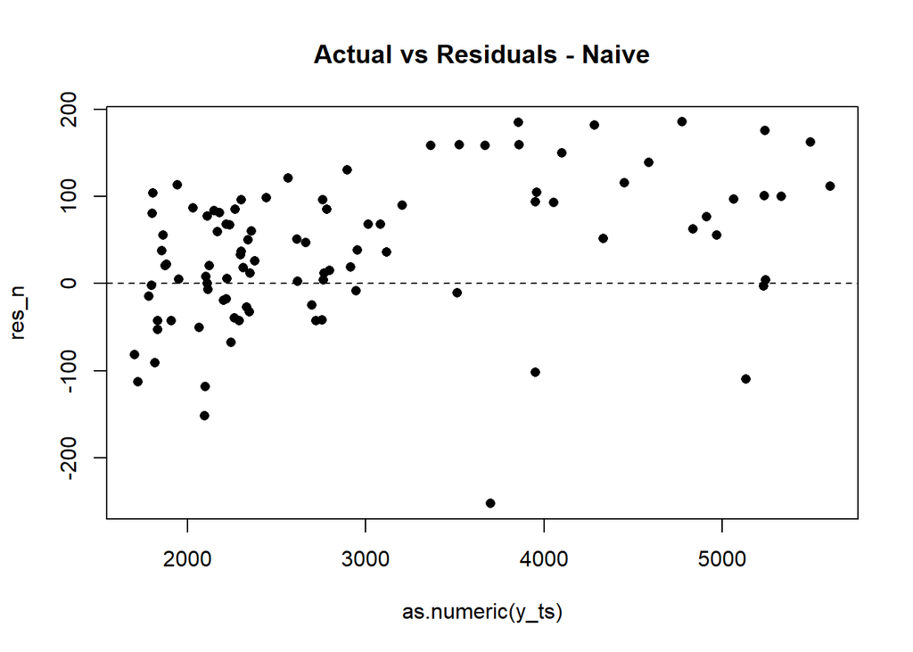

```r
plot(as.numeric(y_ts), res_n, pch = 16,main = "Actual vs Residuals - Naive");abline(h = 0, lty = 2)
```

As actuals increase, residual magnitude increases, many are positive at high levels. Again heteroskedasticity and systematic under-forecasting during strong growth (naive lags the trend).

o Do an ACF plot of the residuals. What does this plot indicate?

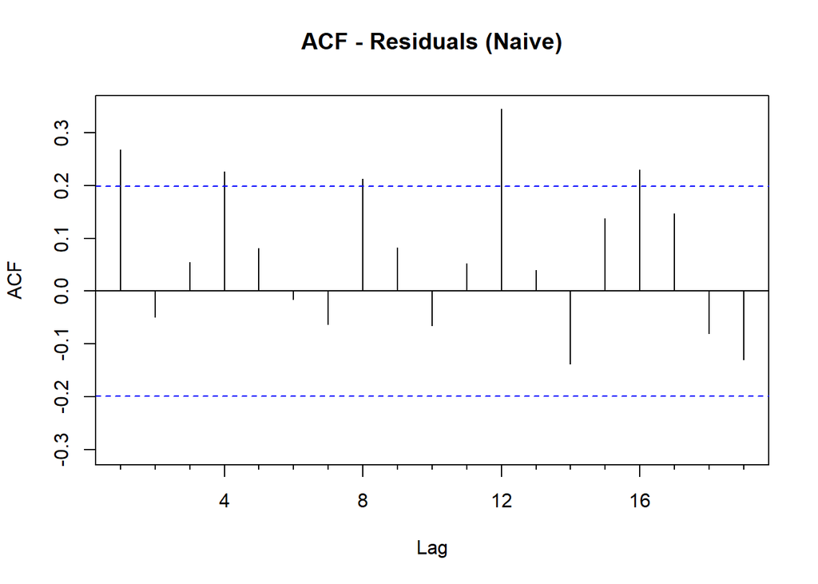

```r
Acf(res_n, main = "ACF - Residuals (Naive)")
```

Several lags outside the bounds of 0.2 (notably lag 1 and some medium lags), but serial correlation remains. Residuals are not white noise, there’s leftover structure of trend dynamics/level-dependent effects that the naive model doesn’t explain.

• Print the five measures of accuracy for this forecasting technique

```r
# ME, RMSE, MAE, MPE, MAPE, etc.
accuracy(naive_forecast)
```

```
##                    ME     RMSE      MAE      MPE     MAPE      MASE      ACF1
## Training set 37.72254 88.50432 70.90326 1.045883 2.436049 0.3823088 0.2676892
```

```r
# Five standard accuracy measures for Naive
acc_naive <- accuracy(naive_forecast)
acc5 <- acc_naive[, c("ME","RMSE","MAE","MPE","MAPE")]
round(acc5, 3)
```

```
##     ME   RMSE    MAE    MPE   MAPE
## 37.723 88.504 70.903  1.046  2.436
```

• Forecast o Time series value for next year. Show table and plot

```r
library(forecast)
# Next 4 quarters (quarterly data)
h <- 4
naive_forecast <- naive(y_ts, h = h)
# Table (point forecast + 80/95% intervals)
round(as.data.frame(naive_forecast), 3)
```

```
##         Point Forecast    Lo 80    Hi 80    Lo 95    Hi 95
## 2025 Q3       5606.114 5492.691 5719.537 5432.649 5779.579
## 2025 Q4       5606.114 5445.710 5766.518 5360.797 5851.431
## 2026 Q1       5606.114 5409.660 5802.568 5305.663 5906.565
## 2026 Q2       5606.114 5379.268 5832.960 5259.183 5953.045
```

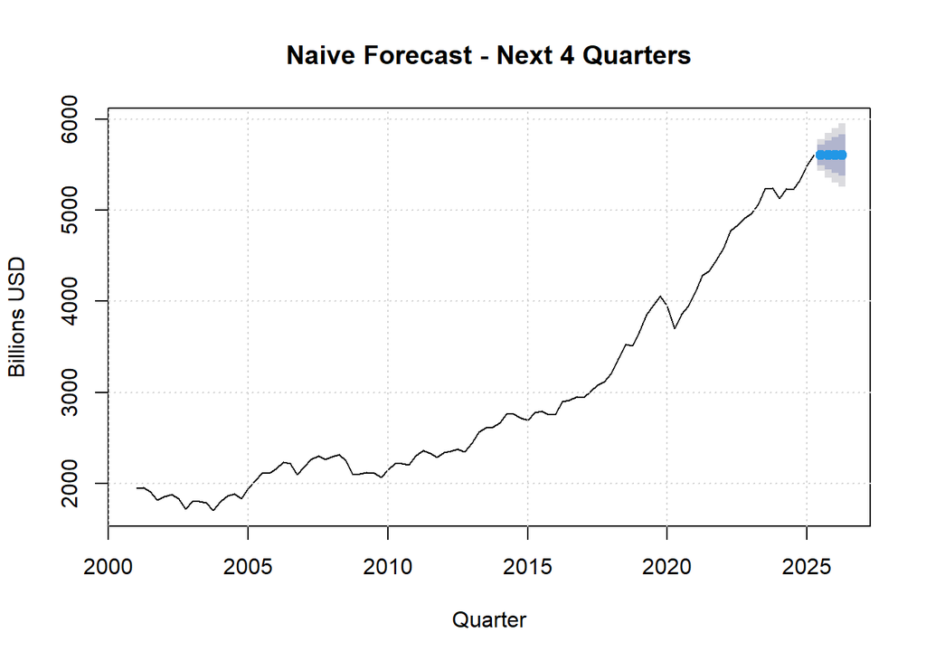

```r
# Plot
plot(naive_forecast, main = "Naive Forecast - Next 4 Quarters",ylab = "Billions USD", xlab = "Quarter")
grid()
```

• Summarize this forecasting technique o How good is the accuracy? The naive model is an acceptable baseline, but its accuracy is limited for this series. The positive mean error (ME) shows it tends to under-forecast because the data are trending upward. RMSE is larger than MAE, which means a few big misses occur around sharp drops or rebounds. The percentage errors indicate usable but not strong performance for planning. This technique is okay for a quick benchmark, but a trend-aware model (e.g., random walk with drift, SES, or ETS with trend) should deliver better accuracy.

o What does it predict the time series value will be in one year?

```r
as.numeric(naive_forecast$mean[4])
```

```
## [1] 5606.114
```

The naive model assumes the series follows a “last-value-persists” pattern (a random walk without drift), so it predicts the series will be 5,606.114 billion USD in one year (i.e., 2026 Q2), which is the same as the last observed value (2025 Q2).

# IV. Simple Moving Averages

• Plot the graph for the time series.

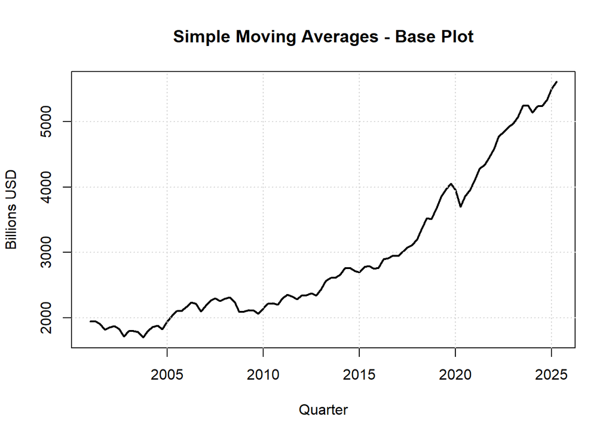

```r
library(forecast)
plot(y_ts, main = "Simple Moving Averages - Base Plot",ylab = "Billions USD",xlab = "Quarter", lwd = 2)
grid()
```

• Show the Simple Moving average of order three on the plot above in Red

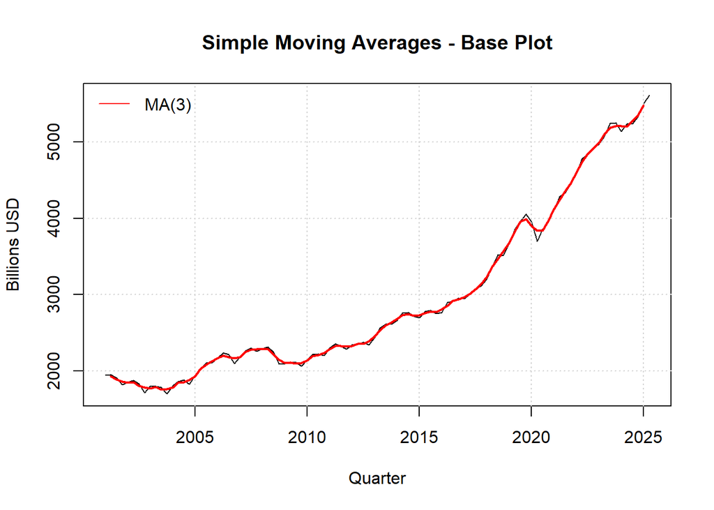

```r
library(forecast)
plot(y_ts, main = "Simple Moving Averages - Base Plot",ylab = "Billions USD", xlab = "Quarter", lwd = 1)
grid()

lines(forecast::ma(y_ts, order = 3),col = "red",lwd = 2)
legend("topleft", "MA(3)", col = "red", lty = 1, bty = "n")
```

• Show the Simple Moving average of order six on the plot above in Blue

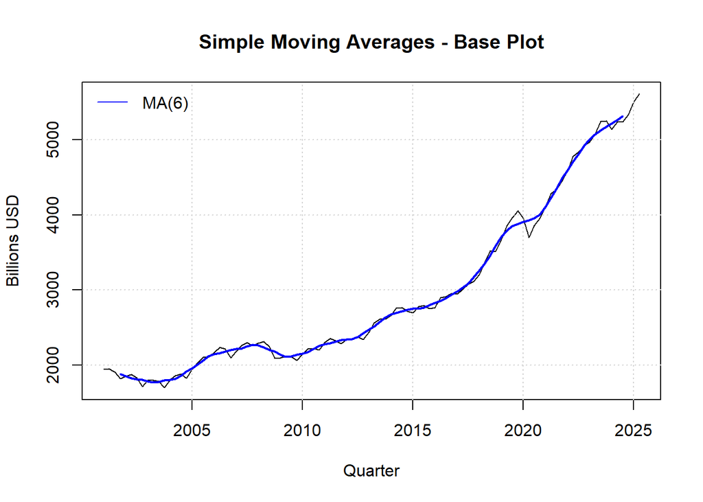

```r
plot(y_ts, main = "Simple Moving Averages - Base Plot",ylab = "Billions USD", xlab = "Quarter", lwd = 1)
grid()

lines(forecast::ma(y_ts, order = 6),col = "blue",lwd = 2)
legend("topleft", "MA(6)", col = "blue", lty = 1, bty = "n")
```

• Show the Simple Moving average of order nine on the plot above in Green

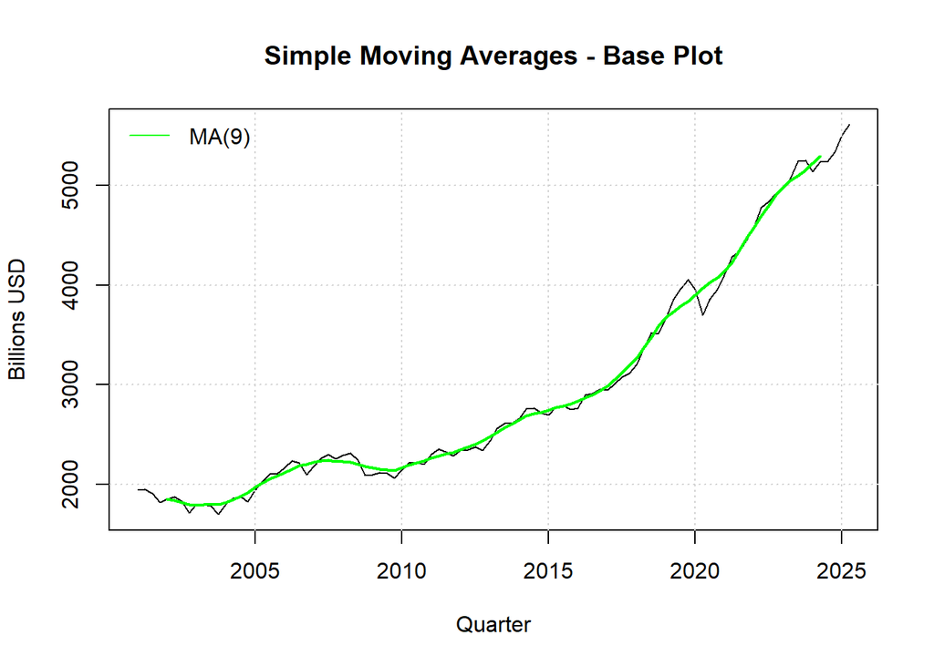

```r
plot(y_ts, main = "Simple Moving Averages - Base Plot",ylab = "Billions USD", xlab = "Quarter", lwd = 1)
grid()

lines(forecast::ma(y_ts, order = 9),col = "green",lwd = 2)
legend("topleft", "MA(9)", col = "Green", lty = 1, bty = "n")
```

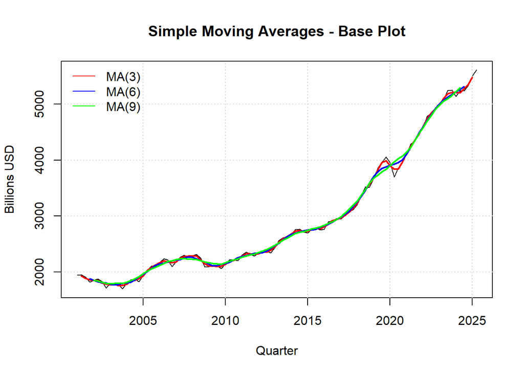

```r
library(forecast)
plot(y_ts, main = "Simple Moving Averages - Base Plot",ylab = "Billions USD", xlab = "Quarter", lwd = 1)
grid()

lines(forecast::ma(y_ts, order = 3),col = "red",lwd = 2)
lines(forecast::ma(y_ts, order = 6),col = "blue",lwd = 2)
lines(forecast::ma(y_ts, order = 9),col = "green",lwd = 2)
legend("topleft", c("MA(3)", "MA(6)", "MA(9)"),col = c("red","blue","green"), lty = 1, bty = "n")
```

• (Bonus) Show the forecast for the next 12 months using one of the simple average orders that you feel works best for the time series Since MA itself doesn’t “project” forward, the common lecture pattern is smoothing with MA(k), then carry the last smoothed value forward using a naive forecast on the smoothed series.

```r
library(forecast)

# Horizon = one year ahead (12 if monthly, 4 if quarterly)
freq <- frequency(y_ts)
h <- if (freq == 12) 12 else 4

# Choose the MA order works best (MA(6))
k <- 6
# smoothed series (ts with NAs at start)
sm <- forecast::ma(y_ts, order = k)

# Forecast: naive on the smoothed series (carry last smoothed value forward)
fc_ma <- naive(na.omit(sm), h = h)

# Table (point forecast + 80/95% intervals)
round(as.data.frame(fc_ma), 3)
```

```
##         Point Forecast    Lo 80    Hi 80    Lo 95    Hi 95
## 2024 Q4       5309.318 5239.013 5379.623 5201.796 5416.841
## 2025 Q1       5309.318 5209.892 5408.745 5157.259 5461.378
## 2025 Q2       5309.318 5187.546 5431.090 5123.084 5495.553
## 2025 Q3       5309.318 5168.708 5449.929 5094.273 5524.363
```

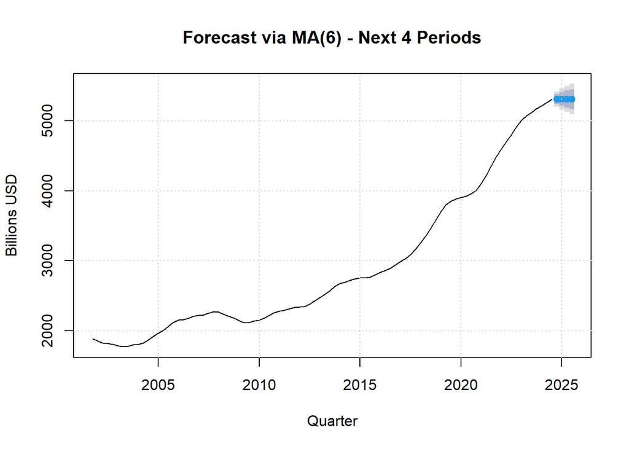

```r
# Plot
plot(fc_ma, main = paste0("Forecast via MA(", k, ") - Next ", h, " Periods"), ylab = "Billions USD", xlab = if (freq==12) "Month" else "Quarter")
grid()
```

• What are your observations of the plot as the moving average order goes up? The line gets smoother as the order increases. Short-term bumps are averaged out. The amplitude of swings is reduced, and peaks and troughs are flattened as order increases. The MA curve reacts more slowly to new changes (more lag) with higher orders. In trending periods, higher-order MAs tend to undershoot on the way up and overshoot on the way down because of more bias around turning points. The start of the series shows more missing/flat segments because a longer window needs more past values. For quarterly data, MA(4) roughly captures a one-year level, but MA(6) or MA(9) smooths even more but adds more lag. So, use a smaller order while needing responsiveness, and use a larger order while needing a stable level and not minding delay. For this upward-trending series, a mid-range order (e.g., MA(6)) balances smoothness with timely response.

#Simple Smoothing • Perform a simple smoothing forecast for the next 12 months for the time series.

```r
library(forecast)

# Horizon = one year ahead (12 if monthly, 4 if quarterly)
freq <- frequency(y_ts)
h <- if (freq == 12) 12 else 4

# Fit SES and forecast
ses_fit <- ses(y_ts, h = h)

# Table (point forecast + 80/95% prediction intervals)
round(as.data.frame(ses_fit), 3)
```

```
##         Point Forecast    Lo 80    Hi 80    Lo 95    Hi 95
## 2025 Q3       5606.103 5492.086 5720.119 5431.729 5780.476
## 2025 Q4       5606.103 5444.867 5767.339 5359.514 5852.692
## 2026 Q1       5606.103 5408.633 5803.572 5304.100 5908.106
## 2026 Q2       5606.103 5378.087 5834.119 5257.382 5954.823
```

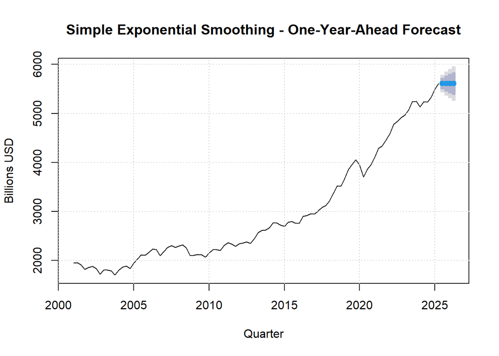

```r
# Plot
plot(ses_fit, main = "Simple Exponential Smoothing - One-Year-Ahead Forecast", ylab = "Billions USD", xlab = if (freq == 12) "Month" else "Quarter")
grid()
```

o What is the value of alpha? What does that value signify?

```r
# Robust alpha extraction across forecast versions
alpha_val <- NA_real_
if (!is.null(ses_fit$model$alpha)) {
  alpha_val <- as.numeric(ses_fit$model$alpha)
} else if (!is.null(ses_fit$model$par) && "alpha" %in% names(ses_fit$model$par)) {
  alpha_val <- as.numeric(ses_fit$model$par[["alpha"]])
} else if (!is.null(ses_fit$model$pars) && "alpha" %in% names(ses_fit$model$pars)) {
  alpha_val <- as.numeric(ses_fit$model$pars[["alpha"]])
}

round(alpha_val, 5)
```

```
## [1] 0.9999
```

```r
# From HoltWinters (simple smoothing)
HW_Simple <- HoltWinters(y_ts, beta = FALSE, gamma = FALSE)
round(HW_Simple$alpha, 5)
```

```
## [1] 0.99996
```

o What is the value of the initial state?

```r
# Initial level (robust across versions)
init_level <- if (!is.null(ses_fit$model$init) && "l" %in% names(ses_fit$model$init)) {ses_fit$model$init[["l"]]} else if (!is.null(ses_fit$model$states) && "l" %in% colnames(ses_fit$model$states)) {ses_fit$model$states[1, "l"]} else NA_real_

round(as.numeric(init_level), 3)
```

```
## [1] 1947.066
```

o What is the value of sigma? What does the sigma signify?

```r
# Sigma = residual standard deviation (innovation scale)
res   <- residuals(ses_fit)
sigma <- sqrt(mean(res^2, na.rm = TRUE))
round(sigma, 3)
```

```
## [1] 88.055
```

Sigma is the standard deviation of the forecast errors (residuals) from the SES model. It measures the typical size of the miss in the same units as the data (billions of USD). Smaller sigma value means the model is fitting more tightly and will produce narrower prediction intervals. Larger sigma value means errors are bigger on average and intervals will be wider. Sigma = 88.055 means the SES model’s typical one-step forecast error is about $88.06B. In plain terms, on average the model’s misses are around 88 billion. Relative to the series level (mean is $2,953B), sigma is roughly 3%. That suggests the SES fit is reasonably tight for a simple smoother, though there’s still meaningful noise the model can’t capture. 88.055 is the residual standard deviation, which is a compact summary of how much the SES forecasts typically deviate from actuals.

• Perform Residual Analysis for this technique. o Do a plot of residuals. What does the plot indicate?

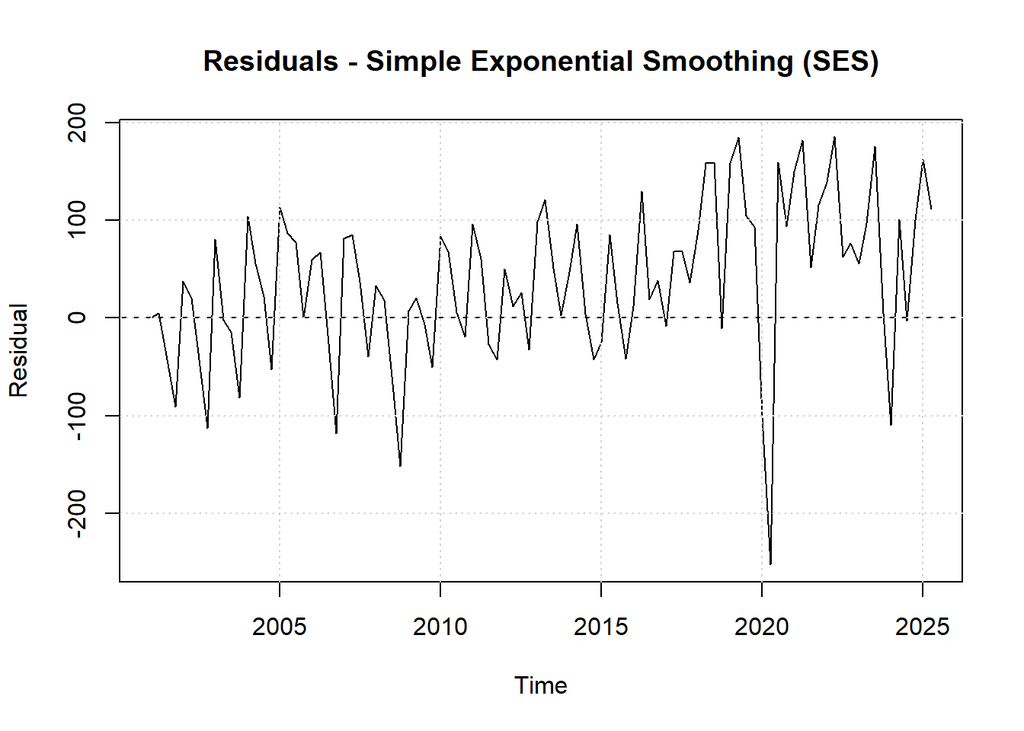

```r
# Residuals from SES
res_ses <- residuals(ses_fit)
plot(res_ses, main = "Residuals - Simple Exponential Smoothing (SES)", ylab = "Residual", xlab = "Time")
abline(h = 0, lty = 2)
grid()
```

Residuals fluctuate around zero which is good, but the spread grows over time, so variance is not perfectly constant. There are runs. After 2017 there are many positive residuals, meaning SES under-forecasts during the strong uptrend. Large negative spikes around 2020 and again later show SES over-forecasted after sudden drops. SES removes some noise but still lags the trend and leaves serial correlation.

o Do a Histogram plot of residuals. What does the plot indicate?

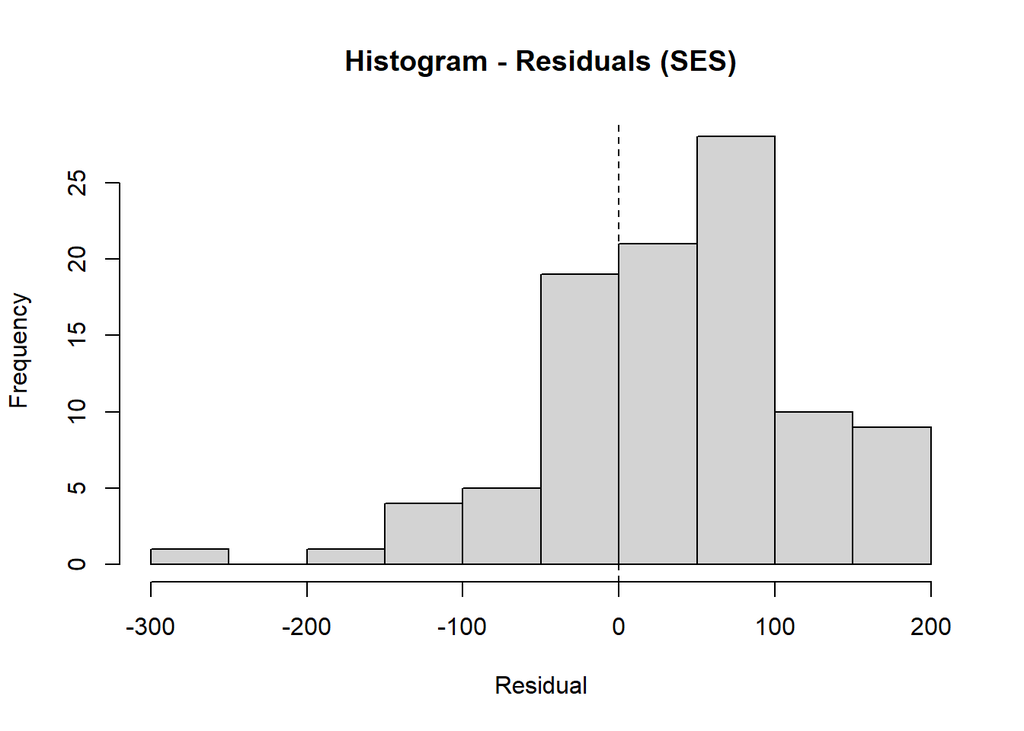

```r
# Histogram of SES residuals
hist(res_ses, breaks = "FD", main = "Histogram - Residuals (SES)", xlab = "Residual")
# reference line at zero
abline(v = 0, lty = 2)
```

The distribution is not perfectly symmetric. It is centered near but slightly above zero, so SES slightly under-forecasts on average. There is a longer left tail, driven by a few large negative errors during sudden drops (e.g., 2020). This asymmetry and tail behavior suggest the model still misses turning points, even though typical errors are moderate.

o Do a plot of fitted values vs. residuals. What does the plot indicate?

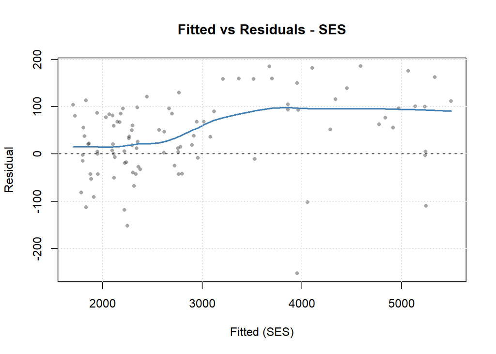

```r
# Fitted vs residuals for SES
f <- as.numeric(fitted(ses_fit))
r <- as.numeric(residuals(ses_fit))

ok <- is.finite(f) & is.finite(r)
f <- f[ok]; r <- r[ok]

plot(f, r, pch = 16, cex = 0.7, col = rgb(0,0,0,0.35), xlab = "Fitted (SES)", ylab = "Residual", main = "Fitted vs Residuals - SES")
abline(h = 0, lty = 2)
lines(lowess(f, r, f = 0.6), lwd = 2, col = "steelblue")
grid()
```

o Do a plot of actual values vs. residuals. What does the plot indicate?

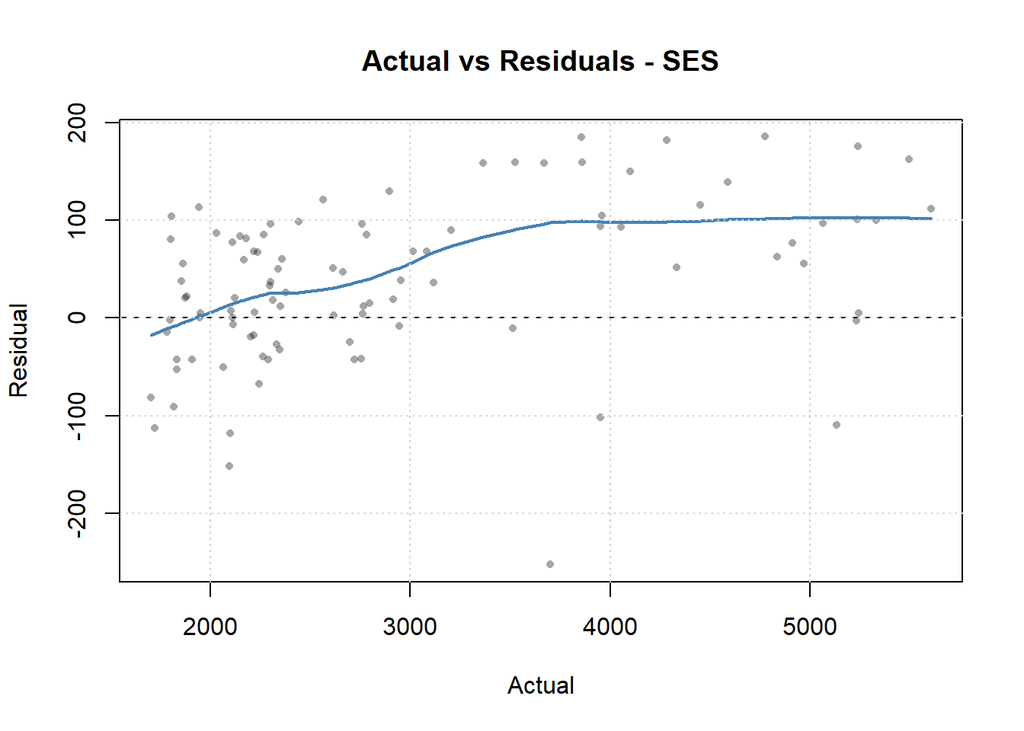

```r
# Actual vs residuals (SES)
a <- as.numeric(y_ts)
r <- as.numeric(residuals(ses_fit))

ok <- is.finite(a) & is.finite(r)
a <- a[ok]; r <- r[ok]

plot(a, r, pch = 16, cex = 0.7, col = rgb(0,0,0,0.35), xlab = "Actual", ylab = "Residual", main = "Actual vs Residuals - SES")
abline(h = 0, lty = 2)
lines(lowess(a, r, f = 0.6), lwd = 2, col = "steelblue")
grid()
```

o Do an ACF plot of the residuals? What does this plot indicate?

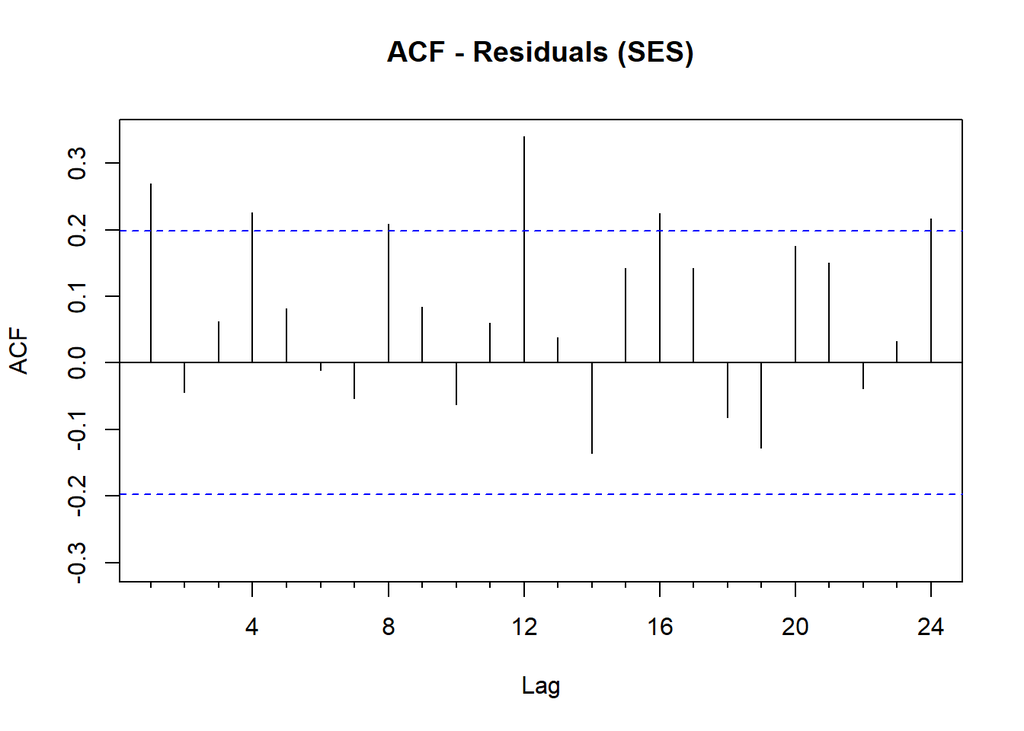

```r
# ACF of SES residuals
res_ses <- residuals(ses_fit)
Acf(na.omit(res_ses), lag.max = 24, main = "ACF - Residuals (SES)")
```

• Print the five measures of accuracy for this forecasting technique

```r
ses_fit <- ses(y_ts, h = if (frequency(y_ts)==12) 12 else 4)
acc_ses <- accuracy(ses_fit)
round(acc_ses[, c("ME","RMSE","MAE","MPE","MAPE")], 3)
```

```
##     ME   RMSE    MAE    MPE   MAPE
## 37.341 88.055 70.183  1.035  2.411
```

• Forecast o Time series value for next year. Show table and plot

```r
# Table (point forecast + 80/95% intervals)
round(as.data.frame(ses_fit), 3)
```

```
##         Point Forecast    Lo 80    Hi 80    Lo 95    Hi 95
## 2025 Q3       5606.103 5492.086 5720.119 5431.729 5780.476
## 2025 Q4       5606.103 5444.867 5767.339 5359.514 5852.692
## 2026 Q1       5606.103 5408.633 5803.572 5304.100 5908.106
## 2026 Q2       5606.103 5378.087 5834.119 5257.382 5954.823
```

```r
# Add year-quarter labels
Quarter <- as.character(zoo::as.yearqtr(time(ses_fit$mean)))
cbind(Quarter, round(as.data.frame(ses_fit), 3))
```

```
##         Quarter Point Forecast    Lo 80    Hi 80    Lo 95    Hi 95
## 2025 Q3 2025 Q3       5606.103 5492.086 5720.119 5431.729 5780.476
## 2025 Q4 2025 Q4       5606.103 5444.867 5767.339 5359.514 5852.692
## 2026 Q1 2026 Q1       5606.103 5408.633 5803.572 5304.100 5908.106
## 2026 Q2 2026 Q2       5606.103 5378.087 5834.119 5257.382 5954.823
```

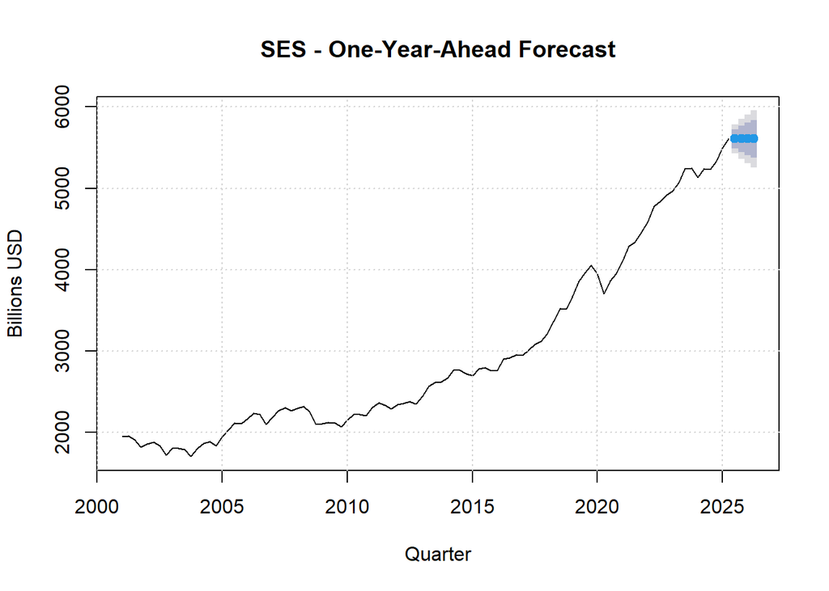

```r
# Plot
plot(ses_fit, main = "SES - One-Year-Ahead Forecast", ylab = "Billions USD", xlab = if (frequency(y_ts)==12) "Month" else "Quarter")
grid()
```

```r
# Extract the one-year-ahead point forecast value
as.numeric(ses_fit$mean[h])
```

```
## [1] 5606.103
```

• Summarize this forecasting technique o How good is the accuracy? The SES model’s accuracy is good for a simple smoother. For the bias, ME is +37.3 which is a small under-forecast on average relative to a 5,000 to 6,000 level. For the scale of errors, MAE (70.2) is smaller than RMSE (88.1), so most misses are modest but a few spikes are larger. For the percent error, MAPE is 2.41%, which is low and usable for planning.

o What does it predict the time series value will be in one year?

```r
as.numeric(ses_fit$mean[4])
```

```
## [1] 5606.103
```

This is the SES point forecast for one year ahead (2026 Q2). SES without trend produces a flat multi-step forecast equal to the last fitted level. The prediction intervals widen with horizon.

o Other observation 1. The prediction intervals widen across the four quarters, so uncertainty grows with horizon. 2. Residuals are autocorrelated and larger at high levels (fan shape), so errors are not white noise and variance is not constant. 3. The model slightly under-forecasts during strong upswings, after sudden drops it can over-forecast briefly. 4. Estimated α gives moderate smoothing so that updates are steady, not jumpy. 5. Sigma is 88 implies typical one-step misses around $88B, 3% is small relative to the series level. 6. SES is a solid baseline, but because it has no trend component, Holt/ETS with trend should capture the upward trajectory better.

#Holt-Winters • Perform a Holt-Winters forecast for the next 12 months for the time series.

```r
library(forecast)
h <- if (frequency(y_ts) == 12) 12 else 4

# Holt-Winters (let R pick α, β, γ if needed), simple if no trend/seasonality detected
HW_full <- HoltWinters(y_ts)
fc_hw   <- forecast(HW_full, h = h)

# Table (point forecast + 80/95% intervals)
round(as.data.frame(fc_hw), 3)
```

```
##         Point Forecast    Lo 80    Hi 80    Lo 95    Hi 95
## 2025 Q3       5694.739 5599.661 5789.817 5549.330 5840.148
## 2025 Q4       5717.252 5581.122 5853.382 5509.059 5925.444
## 2026 Q1       5782.184 5609.899 5954.468 5518.698 6045.670
## 2026 Q2       5910.394 5703.936 6116.853 5594.643 6226.145
```

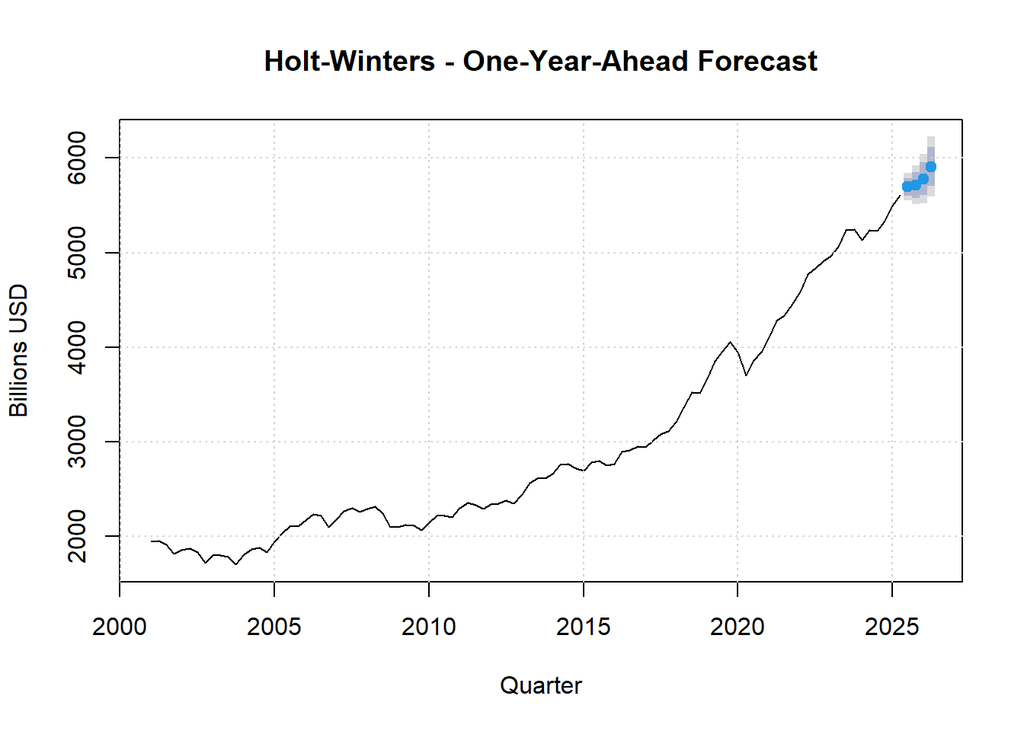

```r
# Plot
plot(fc_hw, main = "Holt-Winters - One-Year-Ahead Forecast", ylab = "Billions USD", xlab = if (frequency(y_ts)==12) "Month" else "Quarter")
grid()
```

```r
# Report parameters and fit quality
c(alpha = round(HW_full$alpha,3), beta  = round(HW_full$beta,3), gamma = round(HW_full$gamma,3))
```

```
## alpha.alpha   beta.beta gamma.gamma
##       0.939       0.092       1.000
```

```r
HW_full$SSE
```

```
## [1] 525309.5
```

```r
accuracy(fc_hw)[, c("ME","RMSE","MAE","MPE","MAPE")]
```

```
##        ME      RMSE       MAE       MPE      MAPE
## 11.951438 74.755595 53.809844  0.441784  1.790363
```

o What is the value of alpha? What does that value signify?

```r
alpha_hw <- HW_full$alpha
round(alpha_hw, 3)
```

```
## alpha
## 0.939
```

Alpha is 0.939, so the level updates aggressively toward the latest quarter. The model is highly responsive with little smoothing, it gives about 94% weight to the newest observation and only 6% to the prior level each update.

o What is the value of beta? What does that value signify?

```r
beta_hw <- HW_full$beta
round(beta_hw, 3)
```

```
##  beta
## 0.092
```

Beta is 0.092. Because alpha is high and beta is low, the model adjusts the level very quickly while keeping the trend changes. That means the model gives about 9% weight to new information when updating the trend (slope) and 91% to the previous trend.

o What is the value of gamma? What does that value signify?

```r
gamma_hw <- HW_full$gamma
round(gamma_hw, 3)
```

```
## gamma
##     1
```

Gamma is 1. The seasonal indices are updated as fast as possible, which means no smoothing. This is very responsive but may chase noise if true seasonality is weak or stable. This means the Holt–Winters model gives 100% weight to the newest seasonal information and 0% to the previous seasonal pattern each update.

o What is the value of initial states for the level, trend, and seasonality? What do these values signify?

```r
lvl0 <- as.numeric(head(HW_full$fitted[,"level"],   1))
tr0  <- as.numeric(head(HW_full$fitted[,"trend"],   1))
sea0 <- as.numeric(head(HW_full$fitted[,"season"],  1))

round(c(level = lvl0, trend = tr0, seasonality = sea0), 3)
```

```
##       level       trend seasonality
##    1915.441     -20.488       0.225
```

Level is 1915.441 This is the model’s starting baseline at the beginning of the series. It’s very close to the first actual value 1947, so the model begins near the observed level. Trend is −20.488 per quarter. This is the initial slope. The negative value means that at the very beginning, the model assumed a slight downward drift each quarter. Seasonality is 0.225. This is the initial seasonal adjustment for that first season. With additive Holt–Winters model, it means this quarter starts about +$0.225B above the baseline. It is small relative to the level.

o What is the value of sigma? What does the sigma signify?

```r
res_hw <- na.omit(residuals(fc_hw))
sigma  <- sqrt(mean(res_hw^2))
round(sigma, 3)
```

```
## [1] 74.756
```

```r
sigma2 <- sqrt(HW_full$SSE / length(res_hw))
round(sigma2, 3)
```

```
## [1] 74.756
```

Sigma is 74.756. This means the Holt–Winters model’s typical one-step error is about $74.76B. Forecasts usually miss the actual by roughly 75 billion.

• Perform Residual Analysis for this technique. o Do a plot of residuals. What does the plot indicate?

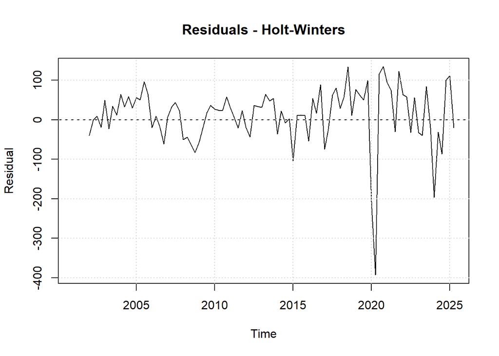

```r
res_hw <- residuals(fc_hw)
plot(res_hw, main = "Residuals - Holt-Winters", ylab = "Residual", xlab = "Time")
abline(h = 0, lty = 2)
grid()
```

Residuals fluctuate around zero. The spread is smaller than with SES, so Holt–Winters fits tighter. There are short same sign errors, and a large negative spike around 2020 from the sudden drop. Variance is more stable overall, though a few later periods still show bigger swings.

o Do a Histogram plot of residuals. What does the plot indicate?

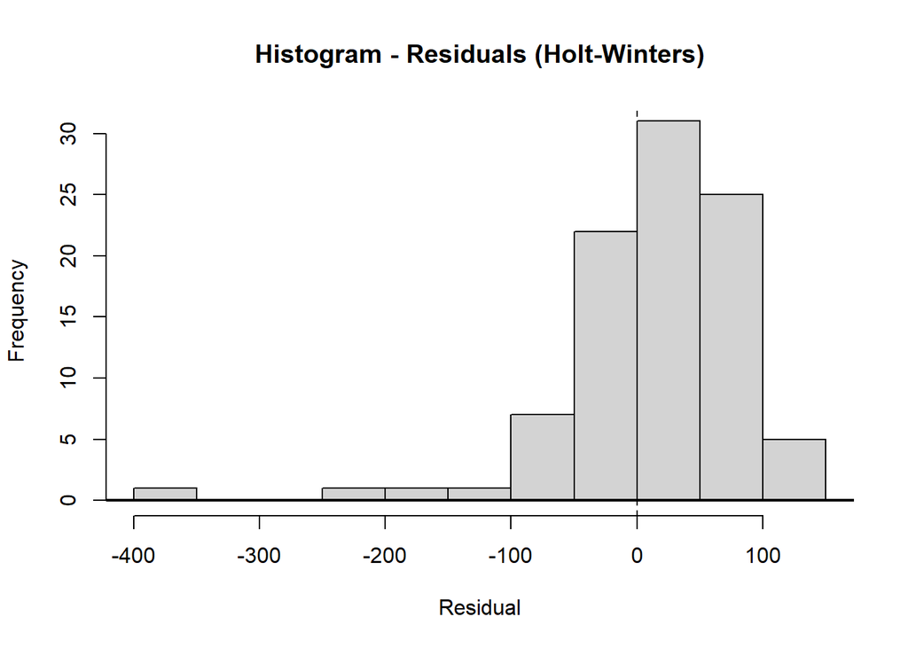

```r
hist(res_hw, breaks = "FD", main = "Histogram - Residuals (Holt-Winters)", xlab = "Residual")
abline(v = 0, lty = 2)
lines(density(na.omit(res_hw)), lwd = 2)
```

The residuals are centered close to zero, so bias is small. Most of values are in a tight band from −50 to +100, showing smaller typical errors than SES. There is a long left tail from a few large negative errors around the 2020 shock, so the distribution isn’t symmetric.

o Do a plot of fitted values vs. residuals. What does the plot indicate?

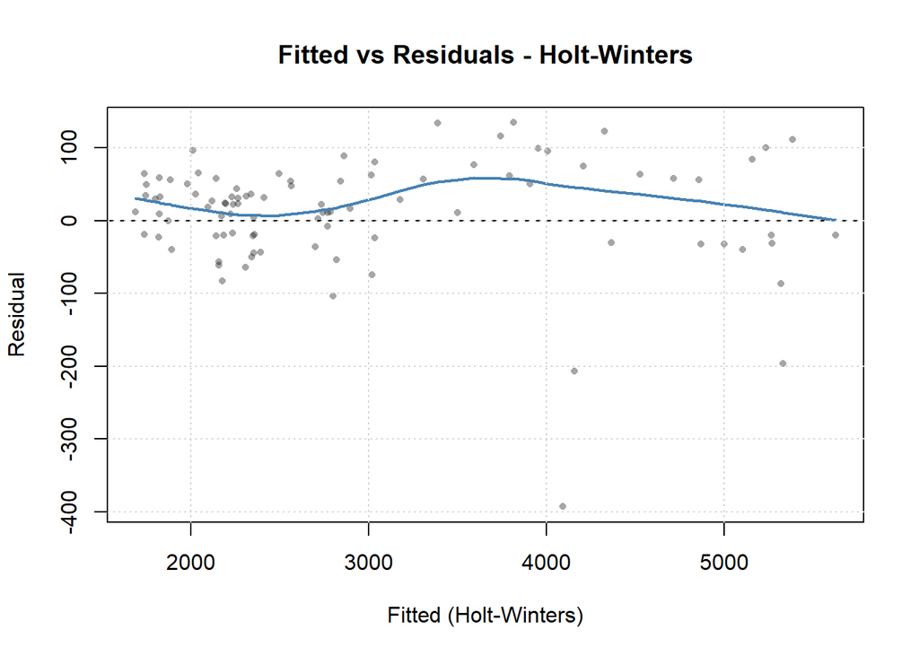

```r
# Fitted vs residuals - Holt-Winters
f <- as.numeric(fitted(fc_hw))
r <- as.numeric(residuals(fc_hw))
ok <- is.finite(f) & is.finite(r)
f <- f[ok]; r <- r[ok]

plot(f, r, pch = 16, cex = 0.7, col = rgb(0,0,0,0.35), xlab = "Fitted (Holt-Winters)", ylab = "Residual", main = "Fitted vs Residuals - Holt-Winters")
abline(h = 0, lty = 2)
lines(lowess(f, r, f = 0.6), lwd = 2, col = "steelblue")
grid()
```

Residuals are centered close to zero across fitted values, so bias is small. The spread is moderate and fairly even, stronger than the fan shape with SES. The smooth line shows a slight hump. There are a few negative shock periods, yet most points cluster tightly.

o Do a plot of actual values vs. residuals. What does the plot indicate?

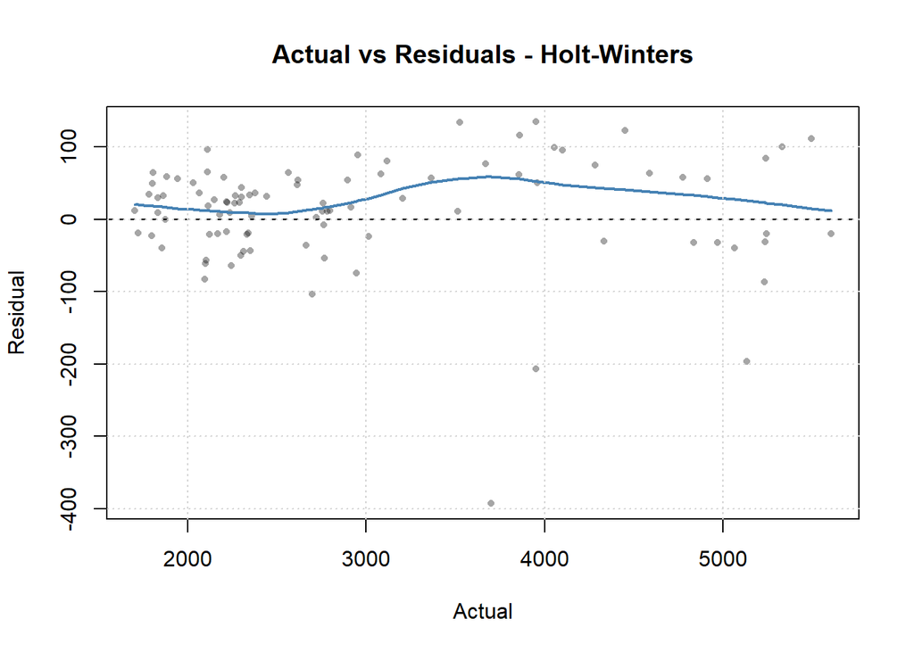

```r
# Actual vs residuals - Holt-Winters
a <- as.numeric(y_ts)
r <- as.numeric(residuals(fc_hw))
ok <- is.finite(a) & is.finite(r)
a <- a[ok]; r <- r[ok]

plot(a, r, pch = 16, cex = 0.7, col = rgb(0,0,0,0.35), xlab = "Actual", ylab = "Residual", main = "Actual vs Residuals - Holt-Winters")
abline(h = 0, lty = 2)
lines(lowess(a, r, f = 0.6), lwd = 2, col = "steelblue")
grid()
```

Residuals are centered near zero across the range of actual values so that little overall bias. The spread is fairly uniform, so variance is closer to constant. The smooth line shows a small hump. There are a few negative outliers persist around shock periods.

o Do an ACF plot of the residuals? What does this plot indicate?

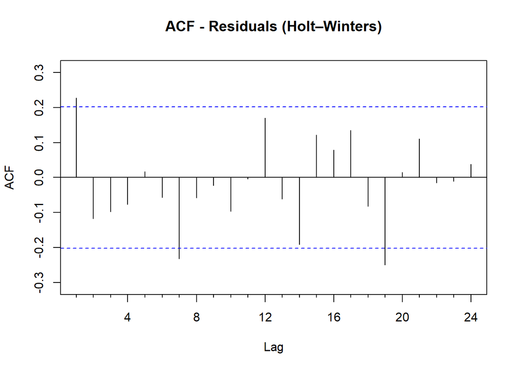

```r
# ACF of Holt-Winters residuals
res_hw <- residuals(fc_hw)
Acf(na.omit(res_hw), lag.max = 24, main = "ACF - Residuals (Holt–Winters)")
```

• Print the five measures of accuracy for this forecasting technique

```r
acc_hw <- accuracy(fc_hw)
round(acc_hw[, c("ME","RMSE","MAE","MPE","MAPE")], 3)
```

```
##     ME   RMSE    MAE    MPE   MAPE
## 11.951 74.756 53.810  0.442  1.790
```

• Forecast o Time series value for next year. Show table and plot

```r
library(forecast)
h <- if (frequency(y_ts) == 12) 12 else 4

# Fit & forecast
HW_full <- HoltWinters(y_ts)
fc_hw   <- forecast(HW_full, h = h)

round(as.data.frame(fc_hw), 3)
```

```
##         Point Forecast    Lo 80    Hi 80    Lo 95    Hi 95
## 2025 Q3       5694.739 5599.661 5789.817 5549.330 5840.148
## 2025 Q4       5717.252 5581.122 5853.382 5509.059 5925.444
## 2026 Q1       5782.184 5609.899 5954.468 5518.698 6045.670
## 2026 Q2       5910.394 5703.936 6116.853 5594.643 6226.145
```

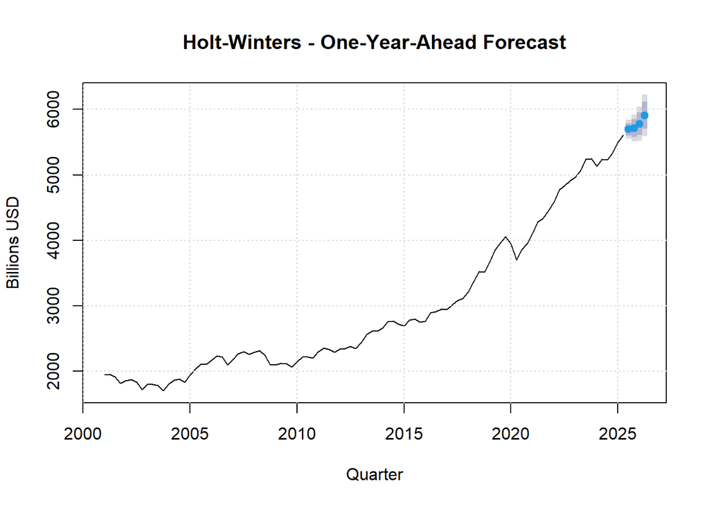

```r
plot(fc_hw, main = "Holt-Winters - One-Year-Ahead Forecast", ylab = "Billions USD", xlab = if (frequency(y_ts)==12) "Month" else "Quarter")
grid()
```

• Summarize this forecasting technique o How good is the accuracy? ME is 11.95 near zero, so little systematic bias. RMSE is 74.76, MAE is 53.81. Both are smaller than SES (RMSE is 88.06, MAE is 70.18), so the fit is tighter. MAPE is 1.79% which is better than SES’s 2.41%. So, Holt–Winters delivers good accuracy here and clearly improves on SES.

o What does it predict the time series value will be in one year?

```r
# One-year-ahead point forecast value (the last row of the table)
as.numeric(fc_hw$mean[h])
```

```
## [1] 5910.394
```

Point forecast (2026 Q2): 5,910.394 billion USD.

o Other observation Parameters imply a very responsive level (α = 0.939), a cautiously updating trend (β = 0.092), and fully responsive seasonality (γ = 1). Forecasts show a continued upward path, and the prediction bands widen with horizon, reflecting growing uncertainty.

#Decomposition • Plot the decomposition of the time series.

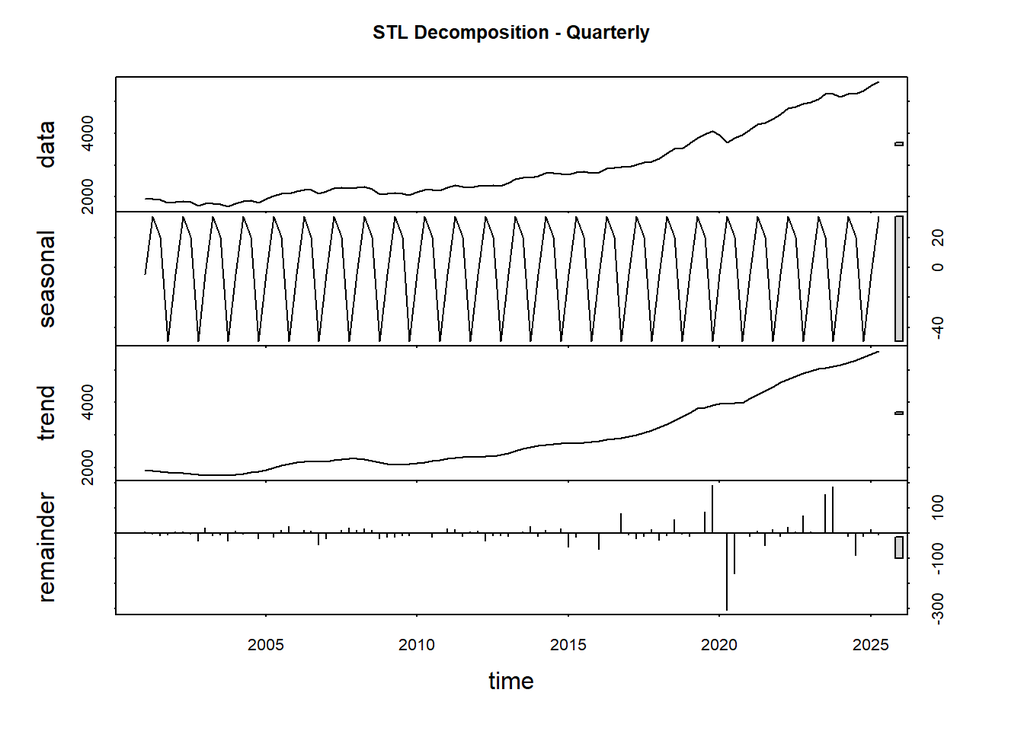

```r
# STL decomposition
fit_stl <- stl(y_ts, s.window = "periodic", robust = TRUE)
plot(fit_stl, main = "STL Decomposition - Quarterly")
```